# High School and Beyond survey Classification Problem

Two hundred observations were randomly sampled from the High School and Beyond survey, a survey conducted on high school seniors by the National Center of Education Statistics.

## Introduction

```r
summary(freeny)
```

```
       y         lag.quarterly.revenue  price.index     income.level
 Min.   :8.791   Min.   :8.791         Min.   :4.278   Min.   :5.821
 1st Qu.:9.045   1st Qu.:9.020         1st Qu.:4.392   1st Qu.:5.948
 Median :9.314   Median :9.284         Median :4.510   Median :6.061
 Mean   :9.306   Mean   :9.281         Mean   :4.496   Mean   :6.039
 3rd Qu.:9.591   3rd Qu.:9.561         3rd Qu.:4.605   3rd Qu.:6.139
 Max.   :9.794   Max.   :9.775         Max.   :4.710   Max.   :6.200
 market.potential
 Min.   :12.97
 1st Qu.:13.01
 Median :13.07
 Mean   :13.07
 3rd Qu.:13.12
 Max.   :13.17
```

## Blorr for Classification

The blorr package offers tools for building and validating binary logistic regression models. It is most suitable for beginner/intermediate R users and those who teach statistics using R. The API is very simple and most of the functions take either a data.frame/tibble or a model as input. blorr use consistent prefix blr_ for easy tab completion.

Let us begin with careful bivariate analysis of each possible variable and the outcome variable. We will use information value and likelihood ratio chi square test for selecting the initial set of predictors for our model. The bivariate analysis is currently avialable for categorical predictors only.

```r
blr_bivariate_analysis(hsb2, honcomp, female, prog, race, schtyp)
```

```
                         Bivariate Analysis
---------------------------------------------------------------------
Variable    Information Value    LR Chi Square    LR DF    LR p-value
---------------------------------------------------------------------
 female           0.10              3.9350          1        0.0473
  prog            0.43              16.1450         2        3e-04
  race            0.33              11.3694         3        0.0099
 schtyp           0.00              0.0445          1        0.8330
---------------------------------------------------------------------
```

Weight of evidence (WoE) is used to assess the relative risk of di¤erent attributes for a characteristic and as a means to transform characteristics into variables. It is also a very useful tool for binning. The WoE for any group with average odds is zero. A negative WoE indicates that the proportion of defaults is higher for that attribute than the overall proportion and indicates higher risk.

The information value is used to rank order variables in terms of their predictive power. A high information value indicates a high ability to discriminate. Values for the information value will always be positive and may be above 3 when assessing highly predictive characteristics. Characteristics with information values less than 0:10 are typically viewed as weak, while values over 0.30 are sought after.

```r
blr_bivariate_analysis(hsb2, female, prog)
```

```
                         Bivariate Analysis
---------------------------------------------------------------------
Variable    Information Value    LR Chi Square    LR DF    LR p-value
---------------------------------------------------------------------
  prog            0.00              0.0528          2        0.9739
---------------------------------------------------------------------
```

## Plot

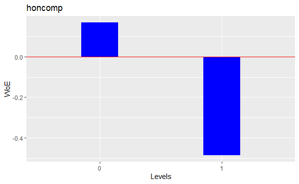

## Multiple Variables

```r
blr_woe_iv_stats(hsb2, honcomp, female)
```

```
Variable: female

                           Weight of Evidence
-------------------------------------------------------------------------
levels    count_0s    count_1s    dist_0s    dist_1s        woe      iv
-------------------------------------------------------------------------
  0          73          18          0.50       0.34       0.38     0.06
  1          74          35          0.50       0.66      -0.27     0.04
-------------------------------------------------------------------------

      Information Value
-----------------------------
Variable    Information Value
-----------------------------
 female          0.1023
-----------------------------
```

```r
blr_woe_iv_stats(hsb2, honcomp, female)
```

```
Variable: female

                           Weight of Evidence
-------------------------------------------------------------------------
levels    count_0s    count_1s    dist_0s    dist_1s        woe      iv
-------------------------------------------------------------------------
  0          73          18          0.50       0.34       0.38     0.06
  1          74          35          0.50       0.66      -0.27     0.04
-------------------------------------------------------------------------

      Information Value
-----------------------------
Variable    Information Value
-----------------------------
 female          0.1023
-----------------------------
```

blr_woe_iv() and blr_woe_iv_stats() are currently avialable for categorical predictors only.

## Stepwise Selection

For the initial/ first cut model, all the independent variables are put into the model. Our goal is to include a limited number of independent variables (5-15) which are all significant, without sacrificing too much on the model performance. The rationale behind not-including too many variables is that the model would be over fitted and would become unstable when tested on the validation sample. The variable reduction is done using forward or backward or stepwise variable selection procedures. We will use blr_step_aic_both() to shortlist predictors for our model.

### Model

```r
model <- glm(honcomp ~ .,data = hsb2, family = binomial(link = 'logit'))
```

```
glm.fit: algorithm did not convergeglm.fit: fitted probabilities numerically 0 or 1 occurred
```

### Selection Summary

```r
blr_step_aic_both(model)
```

```
Stepwise Selection Method
-------------------------

Candidate Terms:

1 . id
2 . female
3 . race
4 . ses
5 . schtyp
6 . read
7 . write
8 . math
9 . science
10 . socst
11 . honcomp


Variables Entered/Removed:

- math added
- science added
- ses added
- read added

No more variables to be added or removed.

                    Stepwise Summary
------------------------------------------------------
Variable     Method       AIC        BIC      Deviance
------------------------------------------------------
math        addition    212.547    219.144     208.547
science     addition    209.197    219.091     203.197
ses         addition    208.372    224.863     198.372
read        addition    208.295    228.085     196.295
------------------------------------------------------
```

### Plot

```r
k <- blr_step_aic_both(model)
```

[output not shown]

```r
plot(k)
```

[output not shown]

# Regression Output

## Model

We can use bivariate analysis and stepwise selection procedure to shortlist predictors and build the model using the glm(). The predictors used in the below model are for illustration purposes and not necessarily shortlisted from the bivariate analysis and variable selection procedures.

Use blr_regress() to generate comprehensive regression output. It accepts either of the following

- model built using glm()
- model formula and data

### Using the model

Let us look at the output generated from blr_regress():

```r
blr_regress(model)
```

[output not shown]

If you want to examine the odds ratio estimates, set odd_conf_limit to TRUE. The odds ratio estimates are not explicitly computed as we observed considerable increase in computation time when dealing with large data sets.

### Using Formula

```r
blr_regress(prog ~ honcomp + female+race,data = hsb2, family = binomial(link = 'logit'))
```

```
- Creating model overview.
- Creating response profile.
- Extracting maximum likelihood estimates.
- Estimating concordant and discordant pairs.
                             Model Overview
------------------------------------------------------------------------
Data Set    Resp Var    Obs.    Df. Model    Df. Residual    Convergence
------------------------------------------------------------------------
  data        prog      200        199           194            TRUE
------------------------------------------------------------------------

                    Response Summary
--------------------------------------------------------
Outcome        Frequency        Outcome        Frequency
--------------------------------------------------------
   0              45               1              105
--------------------------------------------------------

                  Maximum Likelihood Estimates
-----------------------------------------------------------------
 Parameter     DF    Estimate    Std. Error    z value    Pr(>|z|)
-----------------------------------------------------------------
(Intercept)    1      1.5394        0.5714     2.6942      0.0071
 honcomp1      1      0.9444        0.4634     2.0377      0.0416
  female1      1      0.0262        0.3505     0.0748      0.9403
   race2       1     -1.3968        0.8638    -1.6169      0.1059
   race3       1     -0.5316        0.7582    -0.7011      0.4832
   race4       1     -0.5254        0.5897    -0.8910      0.3730
-----------------------------------------------------------------

 Association of Predicted Probabilities and Observed Responses
----------------------------------------------------------------
% Concordant          0.5366          Somers' D         0.2891
% Discordant          0.2959          Gamma             0.2407
% Tied                0.1675          Tau-a             0.0844
Pairs                  6975           c                 0.6204
----------------------------------------------------------------
```

# Model Fit Statistics

Model fit statistics are available to assess how well the model fits the data and to compare two different models.The output includes likelihood ratio test, AIC, BIC and a host of pseudo r-squared measures. You can read more about pseudo r-squared at https://stats.idre.ucla.edu/other/mult-pkg/faq/general/faq-what-are-pseudo-r-squareds/.

## Single Model

```r
blr_model_fit_stats(model)
```

[output not shown]

# Model Validation

# Hosmer Lemeshow Test

Hosmer and Lemeshow developed a goodness-of-fit test for logistic regression models with binary responses. The test involves dividing the data into approximately ten groups of roughly equal size based on the percentiles of the estimated probabilities. The observations are sorted in increasing order of their estimated probability of having an even outcome. The discrepancies between the observed and expected number of observations in these groups are summarized by the Pearson chi-square statistic, which is then compared to chi-square distribution with t degrees of freedom, where t is the number of groups minus 2. Lower values of Goodness-of-fit are preferred.

```r
blr_test_hosmer_lemeshow(model)
```

[output not shown]

# Gains Table & Lift Chart

A lift curve is a graphical representation of the % of cumulative events captured at a specific cut-off. The cut-off can be a particular decile or a percentile. Similar, to rank ordering procedure, the data is in descending order of the scores and is then grouped into deciles/percentiles. The cumulative number of observations and events are then computed for each decile/percentile. The lift curve is the created using the cumulative % population as the x-axis and the cumulative percentage of events as the y-axis.

| decile | total | 1 | 0 | ks | tp | tn | fp | fn | sensitivity | specificity | accuracy |
| --- | --- | --- | --- | --- | --- | --- | --- | --- | --- | --- | --- |
| 1 | 20 | 16 | 4 | 11.027569 | 16 | 91 | 4 | 89 | 15.23810 | 95.78947 | 53.5 |
| 2 | 20 | 14 | 6 | 18.045113 | 30 | 85 | 10 | 75 | 28.57143 | 89.47368 | 57.5 |
| 3 | 20 | 12 | 8 | 21.052632 | 42 | 77 | 18 | 63 | 40.00000 | 81.05263 | 59.5 |
| 4 | 20 | 9 | 11 | 18.045113 | 51 | 66 | 29 | 54 | 48.57143 | 69.47368 | 58.5 |
| 5 | 20 | 11 | 9 | 19.047619 | 62 | 57 | 38 | 43 | 59.04762 | 60.00000 | 59.5 |
| 6 | 20 | 9 | 11 | 16.040100 | 71 | 46 | 49 | 34 | 67.61905 | 48.42105 | 58.5 |
| 7 | 20 | 7 | 13 | 9.022556 | 78 | 33 | 62 | 27 | 74.28571 | 34.73684 | 55.5 |
| 8 | 20 | 10 | 10 | 8.020050 | 88 | 23 | 72 | 17 | 83.80952 | 24.21053 | 55.5 |
| 9 | 20 | 9 | 11 | 5.012531 | 97 | 12 | 83 | 8 | 92.38095 | 12.63158 | 54.5 |
| 10 | 20 | 8 | 12 | 0.000000 | 105 | 0 | 95 | 0 | 100.00000 | 0.00000 | 52.5 |

### Lift Chart

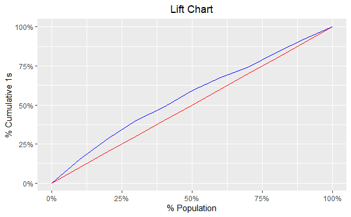

# ROC Curve

ROC curve is a graphical representation of the validity of cut-offs for a logistic regression model. The ROC curve is plotted using the sensitivity and specificity for all possible cut-offs, i.e., all the probability scores. The graph is plotted using sensitivity on the y-axis and 1-specificity on the x-axis. Any point on the ROC curve represents a sensitivity X (1-specificity) measure corresponding to a cut-off. The area under the ROC curve is used as a validation measure for the model – the bigger the area the better is the model.

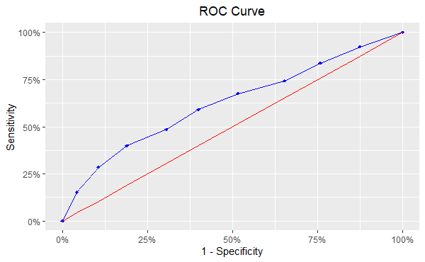

# KS Chart

The KS Statistic is again a measure of model efficiency, and it is created using the lift curve. The lift curve is created to plot % events. If we also plot % non-events on the same scale, with % population at x-axis, we would get another curve. The maximum distance between the lift curve for events and that for non-events is termed as KS. For a good model, KS should be big (>=0.3) and should occur as close to the event rate as possible.

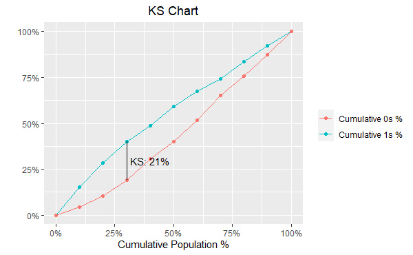

# Decile Lift Chart

The decile lift chart displays the lift over the global mean event rate for each decile. For a model with good discriminatory power, the top deciles should have an event/conversion rate greater than the global mean.

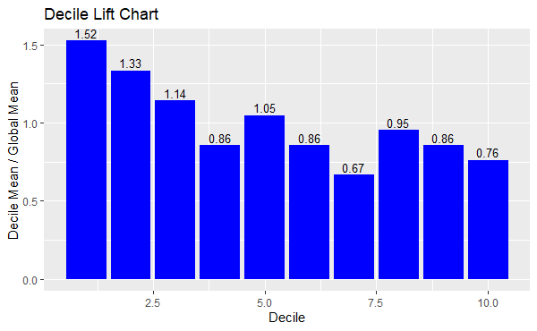

# Capture Rate by Decile

If the model has good discriminatory power, the top deciles should have a higher event/conversion rate compared to the bottom deciles.

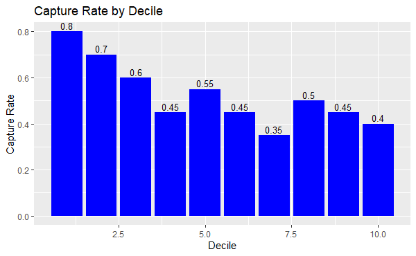

# Lorenz Curve

The Lorenz curve is a simple graphic device which illustrates the degree of inequality in the distribution of thevariable concerned. It is a visual representation of inequality used to measure the discriminatory power of the predictive model.

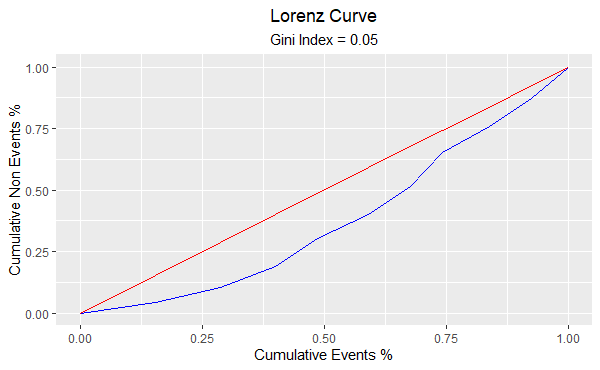

# Residual & Influence Diagnostics

blorr can generate 22 plots for residual, influence and leverage diagnostics.

## Influence Diagnostics

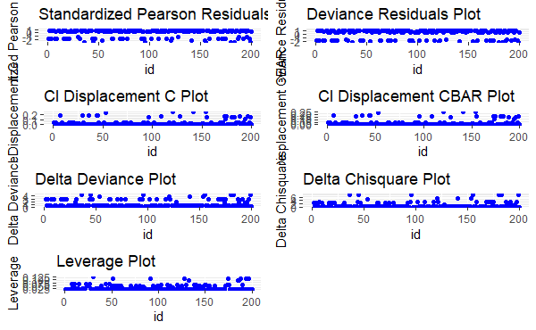

## Leverage Diagnostics

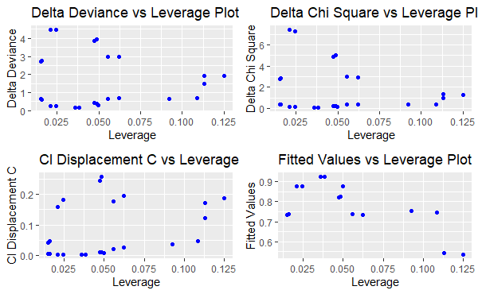

## Fitted Values Diagnostics

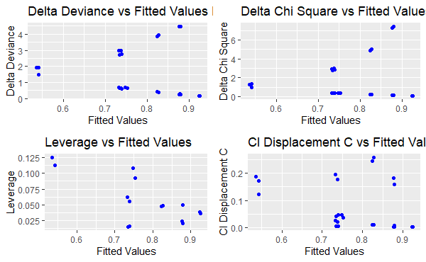

# References

A Short Introduction to the blorr Package Aravind Hebbali Source: vignettes/introduction.Rmd https://blorr.rsquaredacademy.com/articles/introduction.html